# Topic 2

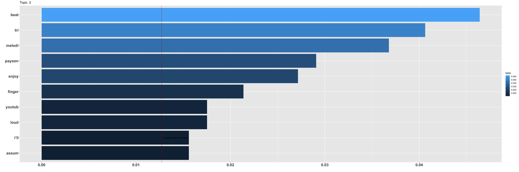

On interpreting beta: the term has a beta probability of being generated from the particular topic.

Values below are gamma : An estimated proportion of words from that document that are generated from that topic.

**Text Record Number: 343** gamma: 17 % likelihood of this document (based on its words) in this topic

**Time signature…Top number is the number of beats in a measure, the bottom number is the type of note that gets the beat. 4/4 is 4 beats per measure, quarter note gets the beat. 6/8 is 6 beats per measure, eighth note gets the beat. For rhythms and more I would recommend reading payson method piano. It covers reading music, practicing, and creativity. Hope this helps, good luck! Payson Method Piano by Andrew Payson https://www.amazon.com/Payson-Method-Piano-Andrew/dp/173293231X/ref=sr_1_2?dchild=1&keywords=payson+method+piano&qid=1586154106&sr=8-2**

**Text Record Number: 1048** gamma: 17 % likelihood of this document (based on its words) in this topic

**It just take time and practice. Be sure you are playing at your level. Start slow and build up speed over time. Eventually you’ll become more and more coordinated. It took me about 3 years to reach an intermediate level. I’m just under four years learning now and my hands just starting to feel coordinated as a unit. It’s definitely not something that happens over night - it just gets easier and easier after lots and lots and lots and lots and lots of practice.

You may feel like your left hand puts you at a disadvantage because melodies tend to be played on the right - and beginner pieces definitely tend to skew towards more emphasis on melody in the right hand- but the further you advance you’ll see that it eventually doesn’t make much of a difference between hands. In fact there was a moment where I was used to playing rather simply with my left hand and all of the sudden once I reached a certain level where the accompaniments (the left hand) were just as complicated and difficult as the melodies. Especially if your interested in Baroque music - the right and left usually play two melodies simultaneously.**

**Text Record Number: 471** gamma: 17 % likelihood of this document (based on its words) in this topic

**Start by determining what you want to play. The classics like Beethoven and Bach? Current pop hits? Jazz? Want to learn to write your own songs?

Now that you’ve got a rough idea what you want to learn … find a teacher. I know a lot of people don’t want to go down that route because it’s expensive or they don’t have time etc. Try it. Even if you only do a few lessons before heading out on your own you will be in such a better place. The good news is with the world of COVID and working from home, you can 100% do this via video chat. No need to leave the comfort of your own home!

When you find a teacher start of talking. Talk about your musical experience, if any. Talk about the kinds of things you want to learn (see the first paragraph), talk about what kind of time you are able to commit daily, weekly, monthly. The more info your teacher is armed with the better they can tailor to your needs and wants.

Last and this is a tricky one. Be prepared to feel nervous; awkward, vulnerable, stupid and a bunch of other things. Don’t worry. You’re new and learning and you will gain confidence. In the mean time get comfortable being awkward and unsure. The more comfortable you can be (especially in the presence of a teacher) the faster you’ll get over it.

Lastly lastly - enjoy it. Playing is fun. Hope it all works out for you and you find you’ve got 88 new best friends.**

**Text Record Number: 368** gamma: 17 % likelihood of this document (based on its words) in this topic

**Payson Method Piano is by far the best method book. It covers how to read music, how to practice, and creativity. I used to practice 3 hours a day and hardly get better and now I practice like 30 min or and hour and make way more progress. I would check it out, good luck!

Payson Method Piano by Andrew Payson

https://www.amazon.com/Payson-Method-Piano-Andrew/dp/173293231X/ref=sr\_1\_2?dchild=1&keywords=payson+method+piano&qid=1586154106&sr=8-2**

**Text Record Number: 484** gamma: 17 % likelihood of this document (based on its words) in this topic

**Payson Method Piano is essential reading…it covers reading music, practicing, and creativity. It’s comprehensive and easy to understand. You can also find free sheet music on the Payson Method website. Good luck!

Payson Method Piano

https://www.amazon.com/Payson-Method-Piano-Andrew/dp/173293231X/ref=sr\_1\_2?dchild=1&keywords=payson+method+piano&qid=1586154106&sr=8-2

Free Sheet Music

http://paysonmethod.com/free-resources/**

**Text Record Number: 1022** gamma: 17 % likelihood of this document (based on its words) in this topic

**Constructive feedback for beginner :)

Hey guys! I’m a piano newby, restarted in February and wanted to get some feedback on my progress so far.

I did take piano lessons when i was a kid for approx 3-4y once a week, but i must say i wasn’t motivated enough and my teacher wasn’t the best, so i had only gotten so far as to play chords in my left hand and melodies in my right. Never really got to play fully two handed. After about 20y i decided to get into piano again, so here i am :)

I’ve been practicing 30min-1h everyday (except some occasional times) with the pianoforall course material. I’ve also been experimenting learning some songs from youtube (learned cardigan from taylor swift and roses of may from final fantasy OST).

I recently played the first 30second of river flows in you and thought i might use it for getting feedback. Still find it hard to play both handed, but it’s getting better. Any advise is appreciated! Thanks!**

**Text Record Number: 919** gamma: 17 % likelihood of this document (based on its words) in this topic

**How long is a piece of string? Everyone is different. Some people will find pieces easy that others find hard and vice versa. Try not to compare yourself to others. The most important thing is that you enjoy playing your piano. Practice can be hard and frustrating. But we persevere. Why? Because the satisfaction and pleasure of playing a beautiful piece of music is totally awesome! Keep going. You’re doing really well with the piece you’re learning 👍**